# AllLife Bank: Customer Segmentation

## Background & Context

AllLife Bank wants to focus on its credit card customer base in the next financial year. They have been advised by their marketing research team that the penetration in the market can be improved. Based on this input, the Marketing team proposes to run personalized campaigns to target new customers as well as upsell to existing customers. Another insight from the market research was that the customers perceive the support services of the bank poorly. Based on this, the Operations team wants to upgrade the service delivery model, to ensure that customer's queries are resolved faster. Head of Marketing and Head of Delivery both decide to reach out to the Data Science team for help.

## Objective

The objective of our analysis is to identify different segments in the existing customer based on their spending patterns as well as past interaction with the bank.

```python
#importing necessary libraries
import warnings

warnings.filterwarnings("ignore")

import pandas as pd
import numpy as np
import matplotlib.pyplot as plt
import seaborn as sns
sns.set_theme(style='darkgrid')

from scipy.spatial.distance import cdist
from sklearn.cluster import KMeans
from scipy.stats import zscore
from sklearn.preprocessing import StandardScaler
from scipy.spatial.distance import pdist
from scipy.cluster.hierarchy import dendrogram, linkage,cophenet
from sklearn.metrics import silhouette_score
from yellowbrick.cluster import KElbowVisualizer, SilhouetteVisualizer
from sklearn.cluster import AgglomerativeClustering

#to print graph without also printing location
%matplotlib inline

# Removes the limit from the number of displayed columns and rows.
# This is so I can see the entire dataframe when I print it
pd.set_option('display.max_columns', None)
# pd.set_option('display.max_rows', None)
pd.set_option('display.max_rows', 200)
```

```python
# Loading the dataset
data = pd.read_csv("Credit Card Customer Data.csv")
```

```python
# copying data to another variable to avoid any changes to original data
df = data.copy()
```

```python
#looking at the first 10 rows of the dataset
df.head(10)
```

|  | Sl_No | Customer Key | Avg_Credit_Limit | Total_Credit_Cards | Total_visits_bank | Total_visits_online | Total_calls_made |
| --- | --- | --- | --- | --- | --- | --- | --- |
| 0 | 1 | 87073 | 100000 | 2 | 1 | 1 | 0 |
| 1 | 2 | 38414 | 50000 | 3 | 0 | 10 | 9 |
| 2 | 3 | 17341 | 50000 | 7 | 1 | 3 | 4 |
| 3 | 4 | 40496 | 30000 | 5 | 1 | 1 | 4 |
| 4 | 5 | 47437 | 100000 | 6 | 0 | 12 | 3 |
| 5 | 6 | 58634 | 20000 | 3 | 0 | 1 | 8 |
| 6 | 7 | 48370 | 100000 | 5 | 0 | 11 | 2 |
| 7 | 8 | 37376 | 15000 | 3 | 0 | 1 | 1 |
| 8 | 9 | 82490 | 5000 | 2 | 0 | 2 | 2 |
| 9 | 10 | 44770 | 3000 | 4 | 0 | 1 | 7 |

```python
#looking at the last 10 rows of the dataset
df.tail(10)
```

|  | Sl_No | Customer Key | Avg_Credit_Limit | Total_Credit_Cards | Total_visits_bank | Total_visits_online | Total_calls_made |
| --- | --- | --- | --- | --- | --- | --- | --- |
| 650 | 651 | 78996 | 195000 | 10 | 1 | 12 | 2 |
| 651 | 652 | 78404 | 132000 | 9 | 1 | 12 | 2 |
| 652 | 653 | 28525 | 156000 | 8 | 1 | 8 | 0 |
| 653 | 654 | 51826 | 95000 | 10 | 0 | 15 | 1 |
| 654 | 655 | 65750 | 172000 | 10 | 1 | 9 | 1 |
| 655 | 656 | 51108 | 99000 | 10 | 1 | 10 | 0 |
| 656 | 657 | 60732 | 84000 | 10 | 1 | 13 | 2 |
| 657 | 658 | 53834 | 145000 | 8 | 1 | 9 | 1 |
| 658 | 659 | 80655 | 172000 | 10 | 1 | 15 | 0 |
| 659 | 660 | 80150 | 167000 | 9 | 0 | 12 | 2 |

### Notes about how to read this dataset:

- Data is of various customers of a bank with their credit limit, the total number of credit cards the customer has, and different channels through which customer has contacted the bank for any queries, different channels include visiting the bank, online and through a call center.

```python
#We're going to go ahead and drop the S1_No and Customer Key columns because they seem irrelevant for analysis
df.drop(['Sl_No', 'Customer Key'], axis=1, inplace=True)
```

```python
#looking at the shape of the dataset
df.shape
```

```
(660, 5)
```

### Observations:

- After dropping 2 columns, the dataset conists of 660 rows and 5 columns (variables).

```python
#checking for duplicates in the dataset
df[df.duplicated()].count()
```

```
Avg_Credit_Limit       11
Total_Credit_Cards     11
Total_visits_bank      11
Total_visits_online    11
Total_calls_made       11
dtype: int64
```

### Observations:

- There seems to be 11 duplicated values and we will go ahead and remove all of them.

```python
df = df[(~df.duplicated())].copy()
```

```python
#checking for null values
df.isnull().sum()
```

```
Avg_Credit_Limit       0
Total_Credit_Cards     0
Total_visits_bank      0
Total_visits_online    0
Total_calls_made       0
dtype: int64
```

### Observations:

- At first glance, there seems to be no null values.

```python
#checking number of unique values in each column
df.nunique()
```

```
Avg_Credit_Limit       110
Total_Credit_Cards      10
Total_visits_bank        6
Total_visits_online     16
Total_calls_made        11
dtype: int64
```

### Observations:

- I am checking number of unique values for each of the variables out of habit, however it truly is unnecessary becacuse the observations in the dataset are entirely quantitative.

```python
#checking datatypes
df.info()
```

```
<class 'pandas.core.frame.DataFrame'>
Int64Index: 649 entries, 0 to 659
Data columns (total 5 columns):
 #   Column               Non-Null Count  Dtype
---  ------               --------------  -----
 0   Avg_Credit_Limit     649 non-null    int64
 1   Total_Credit_Cards   649 non-null    int64
 2   Total_visits_bank    649 non-null    int64
 3   Total_visits_online  649 non-null    int64
 4   Total_calls_made     649 non-null    int64
dtypes: int64(5)
memory usage: 30.4 KB
```

### Observations:

- As previously stated, all values in this dataset are quantitative.

```python
#looking at a general overview of our quantitative varibles
df.describe()
```

|  | Avg_Credit_Limit | Total_Credit_Cards | Total_visits_bank | Total_visits_online | Total_calls_made |
| --- | --- | --- | --- | --- | --- |
| count | 649.000000 | 649.000000 | 649.000000 | 649.000000 | 649.000000 |
| mean | 34878.274268 | 4.708783 | 2.397535 | 2.624037 | 3.590139 |
| std | 37813.736638 | 2.173763 | 1.625148 | 2.952888 | 2.877911 |
| min | 3000.000000 | 1.000000 | 0.000000 | 0.000000 | 0.000000 |
| 25% | 11000.000000 | 3.000000 | 1.000000 | 1.000000 | 1.000000 |
| 50% | 18000.000000 | 5.000000 | 2.000000 | 2.000000 | 3.000000 |
| 75% | 49000.000000 | 6.000000 | 4.000000 | 4.000000 | 5.000000 |
| max | 200000.000000 | 10.000000 | 5.000000 | 15.000000 | 10.000000 |

### Observations:

```python
#to standardize the observations more, we are going to apply z-score transformation so no one particular variable is too strong
dfScaled=df.apply(zscore)
dfScaled.head(10)
```

|  | Avg_Credit_Limit | Total_Credit_Cards | Total_visits_bank | Total_visits_online | Total_calls_made |
| --- | --- | --- | --- | --- | --- |
| 0 | 1.723499 | -1.247087 | -0.860606 | -0.550407 | -1.248443 |
| 1 | 0.400209 | -0.786701 | -1.476410 | 2.499808 | 1.881237 |
| 2 | 0.400209 | 1.054846 | -0.860606 | 0.127419 | 0.142526 |
| 3 | -0.129107 | 0.134072 | -0.860606 | -0.550407 | 0.142526 |
| 4 | 1.723499 | 0.594459 | -1.476410 | 3.177634 | -0.205216 |
| 5 | -0.393766 | -0.786701 | -1.476410 | -0.550407 | 1.533495 |
| 6 | 1.723499 | 0.134072 | -1.476410 | 2.838721 | -0.552958 |
| 7 | -0.526095 | -0.786701 | -1.476410 | -0.550407 | -0.900701 |
| 8 | -0.790753 | -1.247087 | -1.476410 | -0.211494 | -0.552958 |
| 9 | -0.843684 | -0.326314 | -1.476410 | -0.550407 | 1.185753 |

## Exploratory Data Analysis

```python
# While doing uni-variate analysis of numerical variables we want to study their central tendency and dispersion.
# Let us write a function that will help us create boxplots and histograms for any input numerical variables.
# This function takes the numerical column as the input and returns the boxplots and histograms for the variable.
# This will also help us write faster and cleaner code.
def histogram_boxplot(data, xlabel = None, title = None, font_scale=1, figsize=(15,7), bins = None):
    """ Boxplot and histogram combined
    data: 1-d data array
    xlabel: xlabel
    title: title
    font_scale: the scale of the font (default 2)
    figsize: size of fig (default (9,8))
    bins: number of bins (default None / auto)


    """
    mean = np.mean(data)

    sns.set(font_scale=font_scale) # setting the font scale of the seaborn
    f2, (ax_box2, ax_hist2) = plt.subplots(2, sharex=True, gridspec_kw={"height_ratios": (.25, .75)}, figsize=figsize) # creating the 2 subplot
    sns.boxplot(data, ax=ax_box2,showmeans=True,color="steelblue") # boxplot will be created and a star will indicate the mean value of the column
    sns.distplot(data,kde=False, ax=ax_hist2, bins=bins,palette="winter") if bins else sns.distplot(data,kde=False, ax=ax_hist2,color="black") # histogram will be made
    ax_hist2.axvline(mean, color='g', linestyle='--') # mean will shown as vertical line in the histogram
    if xlabel: ax_hist2.set(xlabel=xlabel) # xlabel
    if title: ax_box2.set(title=title) # title of the graph
    plt.show() # for plotting the graph
```

### Observations on Avg_Credit_Limit:

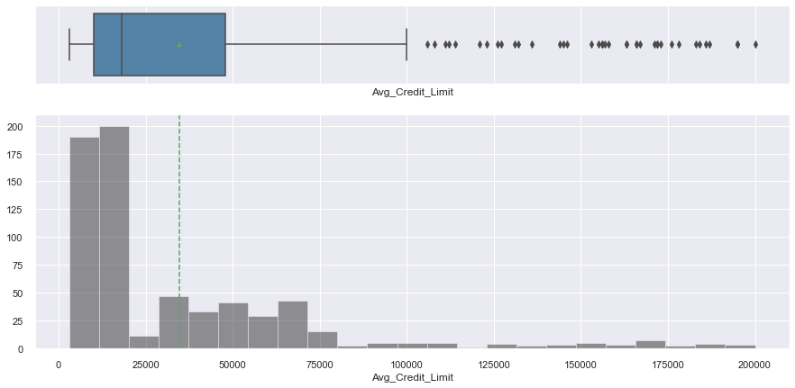

```python
histogram_boxplot(data["Avg_Credit_Limit"])
```

### Observations:

- Avg_Credit_Limit is highly skewed to the right.
- It seems that most individuals have credit limits on the lower end, with very few customers having very high credit limits.
- From our earlier observation, we can see that this is true because the average credit limit sits at close to 35k while the median sits at only 18k.
- Because this observation is so heavily skewed, we will apply a logarithmic transformation to account for this skewness.

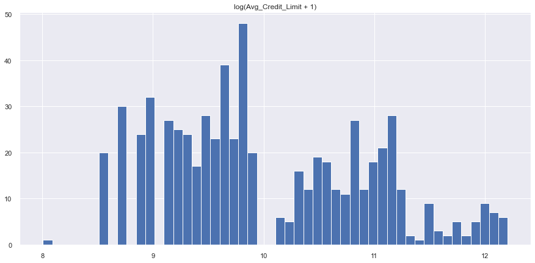

```python
#Due to the skewness of the variable, we are going to apply a logarithmic transformation
plt.hist(np.log(df['Avg_Credit_Limit'] + 1), 50)
plt.gcf().set_size_inches(15, 7)
plt.title('log(Avg_Credit_Limit + 1)')
plt.show()
```

### Observations on Total_Credit_Cards:

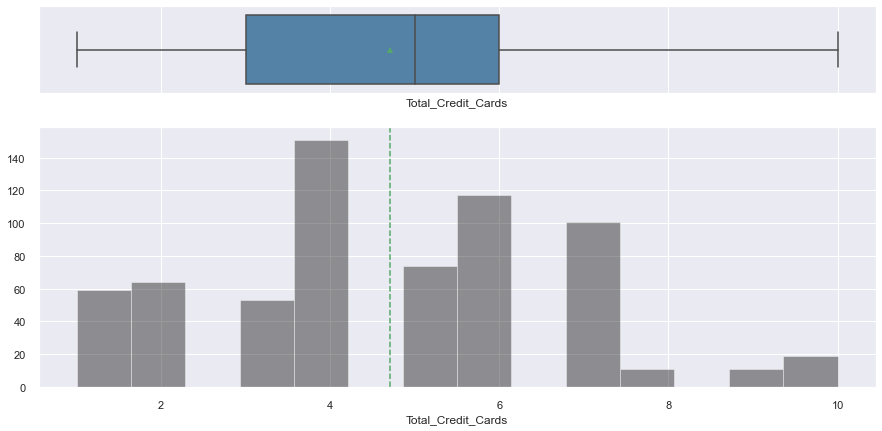

```python
histogram_boxplot(data["Total_Credit_Cards"])
```

### Observations on Total_visits_bank:

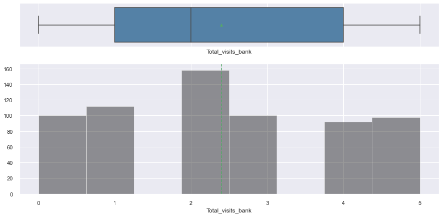

```python
histogram_boxplot(data["Total_visits_bank"])
```

### Observations:

- THere isn't much skewness with total visits to the bank. There is only slight skewness with the mean being only slightly higher than the median.
- It seems that the average customer makes about 2 visits to the bank.

### Observations on Total_visits_online:

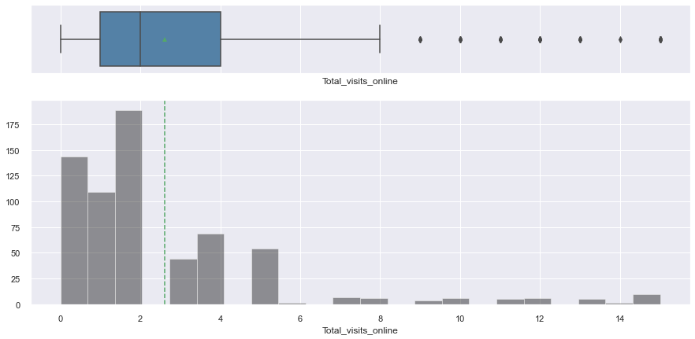

```python
histogram_boxplot(data["Total_visits_online"])
```

### Observations:

- It seems that Total_visits_online is highly skewed to the right.
- The median is slightly lower than the mean, however because you cannot technically have a fraction of a visit, it seems that most customers visit the website twice.
- Customers are more likely to visit less than average than visit the website more than average.
- Due to the high skewness, we will also apply a logarithmic transformation to this variable as well.

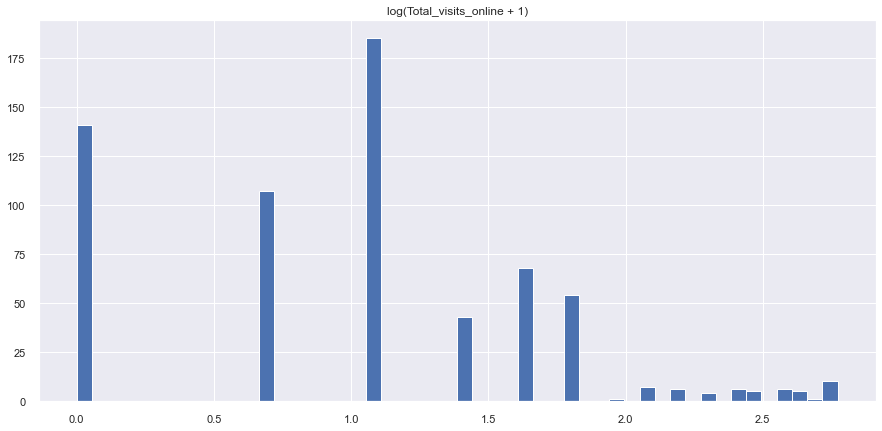

```python
#Due to the skewness of the variable, we are going to apply a logarithmic transformation
plt.hist(np.log(df['Total_visits_online'] + 1), 50)
plt.gcf().set_size_inches(15, 7)
plt.title('log(Total_visits_online + 1)')
plt.show()
```

### Observations on Total_calls_made:

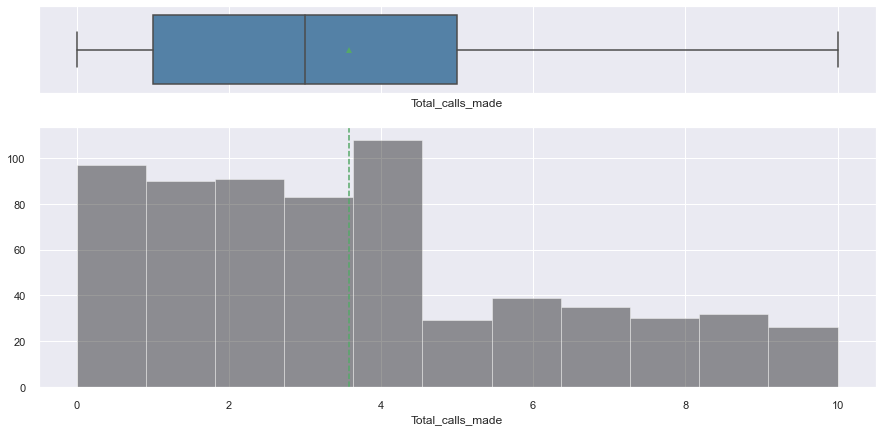

```python
histogram_boxplot(data["Total_calls_made"])
```

### Observations:

- There is slight skewness to the right for this variable.
- It almost seems as if there are 2 segments to this data, with customers who make 4 calls or less calling around the same amount each with customers who make between 5-10 calls also making the same amount of calls except far less on average.

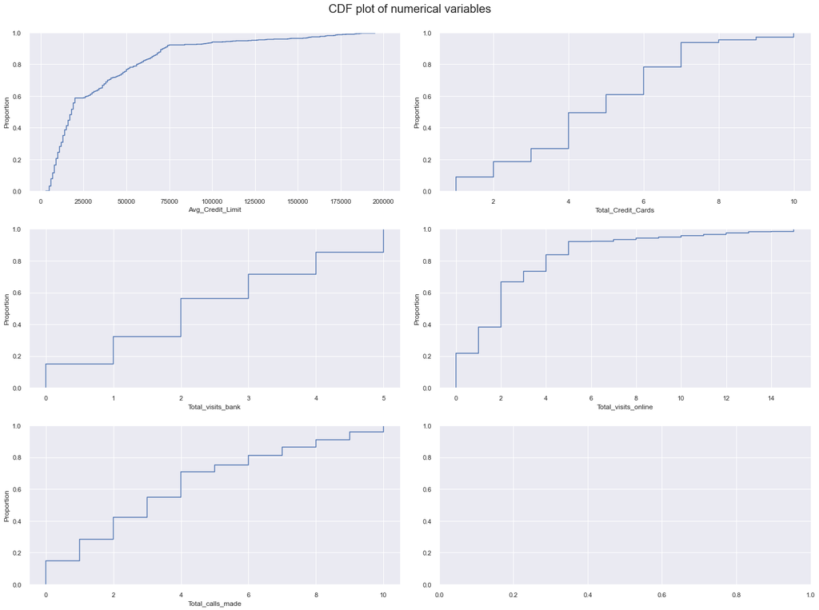

```python
# select numerical columns
all_col = df.select_dtypes(include=np.number).columns.tolist()

fig, axes = plt.subplots(3, 2,  figsize=(20, 15))
fig.suptitle('CDF plot of numerical variables', fontsize=20)
counter = 0
for ii in range(3):
    sns.ecdfplot(ax=axes[ii][0],x=df[all_col[counter]])
    counter = counter+1
    if counter != 5:
        sns.ecdfplot(ax=axes[ii][1],x=df[all_col[counter]])
        counter = counter+1
    else:
        pass


fig.tight_layout(pad=2.0)
```

## Bivariate Analysis

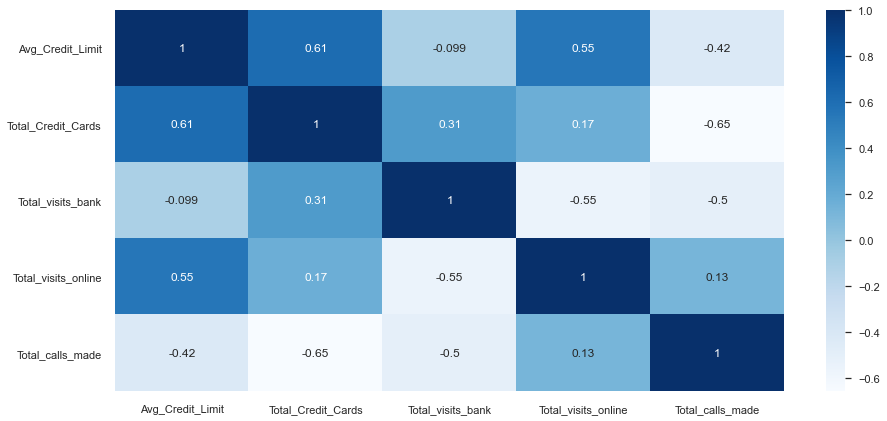

```python
plt.figure(figsize=(15,7))
sns.heatmap(df.corr(),annot=True, cmap="Blues")
plt.show()
```

### Observations:

- There are a few fairly strong correlations within this dataset. The most notable I believe is the positive correlations between Avg_Credit_Limit and Total_Credit_Cards (0.61) and Avg_Credit_Limit and Total_visits_online (0.55).
- There is a slight correlation between Total_visits_bank and Total_Credit Cards at 0.31 however it is incredibly weak.
- Some interesting negative correlations to note are between Total_calls_made and Avg_Credit_Limit at -0.42, Total_Credit Cards and Total_calls_made at -0.65, Total_visits_bank and Total_visits_online at -0.55 (this correlation is unsurprising), and Total_visits_bank and Total_calls_made at -0.5 (also unsurprising).

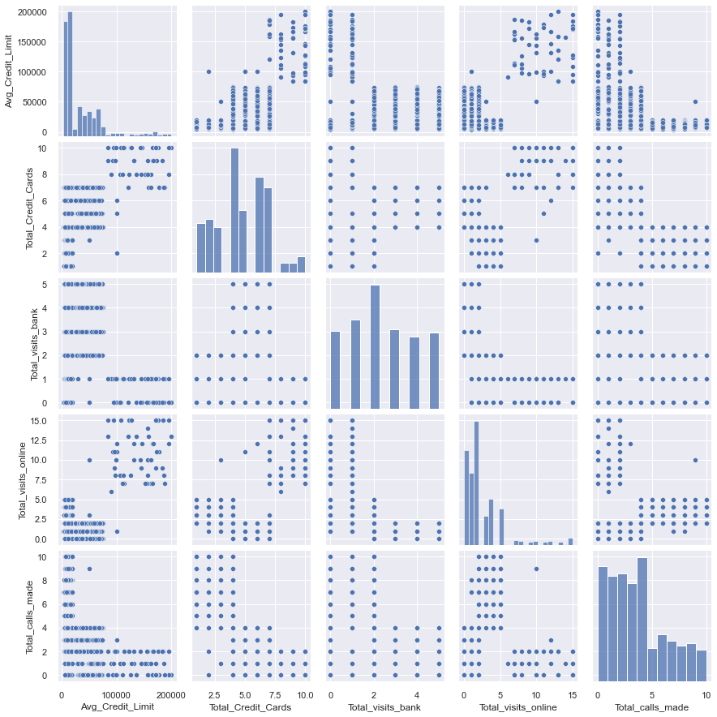

```python
sns.pairplot(df);
```

### Observations:

```python
# variables used for clustering
all_col
```

```
['Avg_Credit_Limit',
 'Total_Credit_Cards',
 'Total_visits_bank',
 'Total_visits_online',
 'Total_calls_made']
```

```python
# Scaling the dataset before clustering
scaler=StandardScaler()
subset=df[all_col].copy()
subset_scaled = scaler.fit_transform(subset)
```

```python
# Creating a dataframe of the above results
subset_scaled_df = pd.DataFrame(subset_scaled,columns=subset.columns)
```

## K-Means Clustering

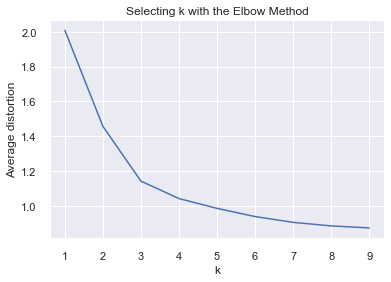

```python
clusters=range(1,10)
meanDistortions=[]

for k in clusters:
    model=KMeans(n_clusters=k)
    model.fit(subset_scaled)
    prediction=model.predict(dfScaled)
    meanDistortions.append(sum(np.min(cdist(subset_scaled, model.cluster_centers_, 'euclidean'), axis=1)) / subset_scaled.shape[0])


plt.plot(clusters, meanDistortions, 'bx-')
plt.xlabel('k')
plt.ylabel('Average distortion')
plt.title('Selecting k with the Elbow Method')
```

### Observations:

- The appropriate value of K seems to be 3.

```python
sil_score = []
cluster_list = list(range(2,10))
for n_clusters in cluster_list:
    clusterer = KMeans(n_clusters=n_clusters)
    preds = clusterer.fit_predict((subset_scaled_df))
    #centers = clusterer.cluster_centers_
    score = silhouette_score(subset_scaled_df, preds)
    sil_score.append(score)
    print("For n_clusters = {}, silhouette score is {})".format(n_clusters, score))
```

```
For n_clusters = 2, silhouette score is 0.41800025566689647)
For n_clusters = 3, silhouette score is 0.516281010855363)
For n_clusters = 4, silhouette score is 0.3570238219413198)
For n_clusters = 5, silhouette score is 0.27283976810835836)
For n_clusters = 6, silhouette score is 0.2569035285862428)
For n_clusters = 7, silhouette score is 0.24852153855121553)
For n_clusters = 8, silhouette score is 0.23099271848541467)
For n_clusters = 9, silhouette score is 0.22618750637801996)
```

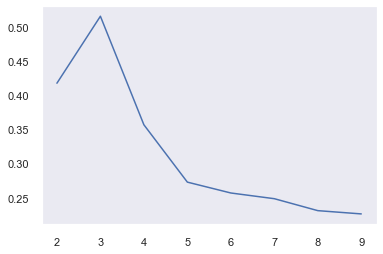

```python
plt.plot(cluster_list,sil_score)
plt.grid()
```

### Observations:

- For silhouette score, it seems that 3 is a good value for k.

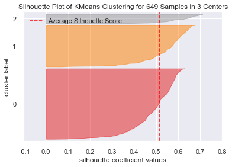

```python
#Finding optimal no. of clusters with silhouette coefficients
visualizer = SilhouetteVisualizer(KMeans(3, random_state = 1))
visualizer.fit(subset_scaled_df)
visualizer.show();
```

```python
kmeans = KMeans(n_clusters=3, random_state=0)
kmeans.fit(subset_scaled_df)
```

```
KMeans(n_clusters=3, random_state=0)
```

```python
subset_scaled_df['K_means_segments'] = kmeans.labels_
```

```python
cluster_profile = subset_scaled_df.groupby('K_means_segments').mean()
```

```python
cluster_profile
```

| K_means_segments | Avg_Credit_Limit | Total_Credit_Cards | Total_visits_bank | Total_visits_online | Total_calls_made |
| --- | --- | --- | --- | --- | --- |
| 0 | -0.021354 | 0.372791 | 0.669127 | -0.556683 | -0.555718 |
| 1 | -0.599145 | -1.057516 | -0.894044 | 0.317578 | 1.147989 |
| 2 | 2.809656 | 1.855918 | -1.106928 | 2.804830 | -0.872881 |

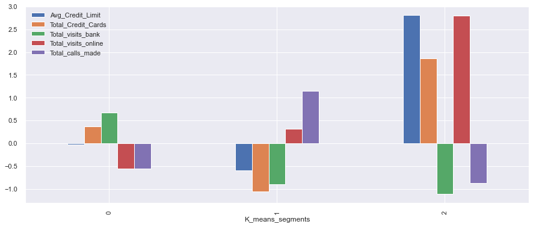

```python
subset_scaled_df.groupby('K_means_segments').mean().plot.bar(figsize=(15,6));
```

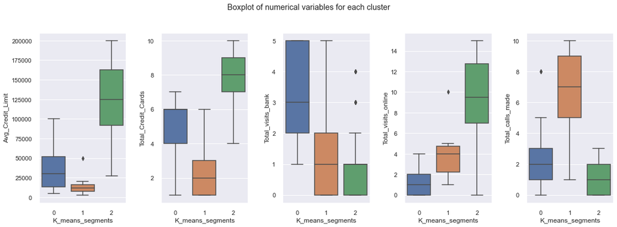

```python
fig, axes = plt.subplots(1, 5,  figsize=(16, 6))
fig.suptitle('Boxplot of numerical variables for each cluster')
counter = 0
for ii in range(5):
    sns.boxplot(ax=axes[ii],y=df[all_col[counter]],x=subset_scaled_df['K_means_segments'])
    counter = counter+1

fig.tight_layout(pad=2.0)
```

### Observations & Insights:

Cluster 0:

- These customers have an average credit limit around the average credit limit of the sample, which is at about 35k.
- These customers have a few more credit cards than average (avg in this sample is 5).
- Customers of this cluster prefer to visit the bank in person as opposed to calling or visiting the website. This is noted by the fact that the individuals tend to visit the bank more than average and call and visit the website less than average.

Cluster 1:

- Customers of Cluster 1 have lower credit limits than the average.
- 50% of these customers only have 2 credit cards, which is notably lower than the average of 5 cards.
- 75% of these customers only visit the bank twice, with 50% only visiting once.
- If these customers are seeking assistance, they opt to make phone calls. This is noted by the fact that they make more calls to the bank than the other 2 clusters by far.
- Even though these customers will visit online slightly more than average, they will still much prefer to make a phone call to seek assistance.

Cluster 2:

- Cluster 2 is the high profile customer.
- These customers have incredibly high credit limits and a large amount of credit cards, much higher than the average in both categories.
- These customers are highly independent. They prefer to visit online for all of their banking needs, visiting online far, FAR more frequently than the other clusters.
- These individuals visit the bank and make phone calls to the bank FAR less frequently than the other two clusters. As noted earlier, these customers are highly independent.

## Hierarchical Clustering

```python
# cophenet index is a measure of the correlation between the distance of points in feature space and distance on dendrogram
# closer it is to 1, the better is the clustering
distance_metrics = [ 'Euclidean','Chebyshev','Mahalanobis','Cityblock']
linkage_methods = ['Single', 'Complete', 'Average', 'Weighted']
high_cophenet_corr = 0
high_dm_lm = [0,0]
for dm in distance_metrics:
    for lm in linkage_methods:
        Z = linkage(subset_scaled_df, metric=dm)
        c, coph_dists = cophenet(Z , pdist(subset_scaled_df))
        print('Cophenetic correlation for distance metrics {} and linkage method {} is {}'.format(dm,lm,c))
        if high_cophenet_corr < c:
            high_cophenet_corr = c
            high_dm_lm[0] = dm
            high_dm_lm[1] = lm
```

```
Cophenetic correlation for distance metrics Euclidean and linkage method Single is 0.8782863872563746
Cophenetic correlation for distance metrics Euclidean and linkage method Complete is 0.8782863872563746
Cophenetic correlation for distance metrics Euclidean and linkage method Average is 0.8782863872563746
Cophenetic correlation for distance metrics Euclidean and linkage method Weighted is 0.8782863872563746
Cophenetic correlation for distance metrics Chebyshev and linkage method Single is 0.8976424680148912
Cophenetic correlation for distance metrics Chebyshev and linkage method Complete is 0.8976424680148912
Cophenetic correlation for distance metrics Chebyshev and linkage method Average is 0.8976424680148912
Cophenetic correlation for distance metrics Chebyshev and linkage method Weighted is 0.8976424680148912
Cophenetic correlation for distance metrics Mahalanobis and linkage method Single is 0.8953021845210309
Cophenetic correlation for distance metrics Mahalanobis and linkage method Complete is 0.8953021845210309
Cophenetic correlation for distance metrics Mahalanobis and linkage method Average is 0.8953021845210309
Cophenetic correlation for distance metrics Mahalanobis and linkage method Weighted is 0.8953021845210309
Cophenetic correlation for distance metrics Cityblock and linkage method Single is 0.8402227893582106
Cophenetic correlation for distance metrics Cityblock and linkage method Complete is 0.8402227893582106
Cophenetic correlation for distance metrics Cityblock and linkage method Average is 0.8402227893582106
Cophenetic correlation for distance metrics Cityblock and linkage method Weighted is 0.8402227893582106
```

```python
print('Highest cophenetic correlation is {}, which is obtained with {} distance metric and {} linkage method.'.format(high_cophenet_corr ,high_dm_lm[0],high_dm_lm[1]))
```

```
Highest cophenetic correlation is 0.8976424680148912, which is obtained with Chebyshev distance metric and Single linkage method.
```

### Observations:

- We see that the high cophenetic correlation is obtained with the Chebyshev distance metric and Single linkage method.
- Let's see the dendogram of different linkage methods.

### Exploring 'centroid', 'median', and 'ward' linkage methods which require only Euclidean distance metrics

```python
linkage_methods = ['single', 'complete', 'average','median','ward', 'weighted']
high_cophenet_corr = 0
high_dm_lm = [0,0]

for lm in linkage_methods:
    Z = linkage(subset_scaled_df, metric='euclidean', method=lm)
    c, coph_dists = cophenet(Z , pdist(subset_scaled_df))
    print('Cophenetic correlation for distance metrics {} and linkage method {} is {}'.format('euclidean',lm,c))
    if high_cophenet_corr < c:
        high_cophenet_corr = c
        high_dm_lm[0] = dm
        high_dm_lm[1] = lm
print('*'*110)
print('Highest cophenetic correlation is {}, which is obtained with {} distance metric and {} linkage method.'.format(high_cophenet_corr ,high_dm_lm[0],high_dm_lm[1]))
```

```
Cophenetic correlation for distance metrics euclidean and linkage method single is 0.8782863872563746
Cophenetic correlation for distance metrics euclidean and linkage method complete is 0.8854872581962318
Cophenetic correlation for distance metrics euclidean and linkage method average is 0.9167886114950704
Cophenetic correlation for distance metrics euclidean and linkage method median is 0.8888158900099539
Cophenetic correlation for distance metrics euclidean and linkage method ward is 0.7756167152597446
Cophenetic correlation for distance metrics euclidean and linkage method weighted is 0.9107193273405108
Highest cophenetic correlation is 0.9167886114950704, which is obtained with Cityblock distance metric and average linkage method.
```

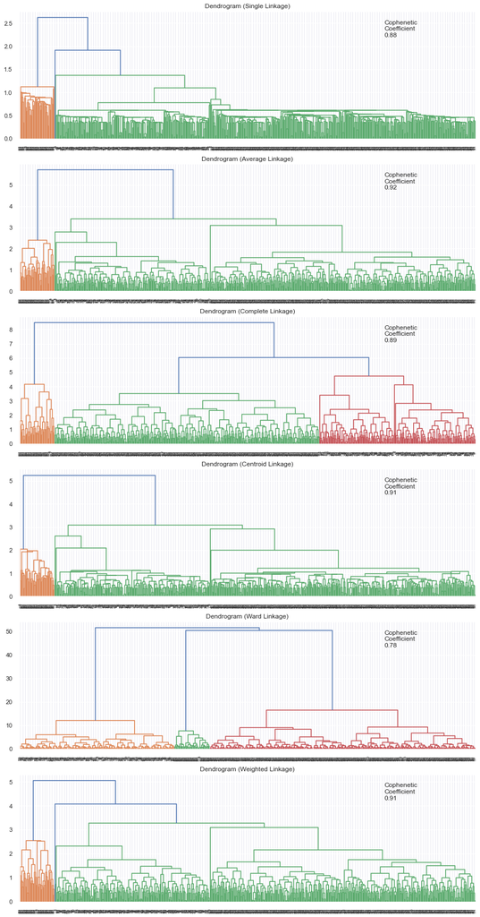

```python
# List of all linkage methods to check
methods = ['single',
           'average',
           'complete',
           'centroid',
           'ward',
          'weighted']

# Calculate the pairwise distance form the dataset to be used in the cophenetic correlation calculation
#pw_distance = pdist(credit_scaled)

# Create lists to save results of coph calculation
compare_cols = ['Linkage', 'Cophenetic Coefficient']
compare = []

# Create a subplot image
fig, axs = plt.subplots(len(methods), 1, figsize=(15, 30))

# Enumerate through the list of all methods above
# Get linkage, plot dendrogram, calculate cophenetic coefficient
for i, method in enumerate(methods):

    Z = linkage(subset_scaled_df, metric='euclidean', method=method)

    dendrogram(Z, ax=axs[i]);
    axs[i].set_title(f'Dendrogram ({method.capitalize()} Linkage)')
    coph_corr, coph_dist = cophenet(Z, pdist(subset_scaled_df))
    axs[i].annotate(f'Cophenetic\nCoefficient\n{coph_corr:0.2f}',
                    (0.80, 0.80),
                    xycoords='axes fraction')
    compare.append([method, coph_corr])
```

### Observations:

- It seems ward linkage has the clearest and most distinct clusters.
- Following this, it seems that complete linkage has the next most distinct clusters.

```python
# Create and print dataframe to compare Cophenetic Coefficient for each linkage
df_cc = pd.DataFrame(compare, columns=compare_cols)
df_cc
```

|  | Linkage | Cophenetic Coefficient |
| --- | --- | --- |
| 0 | single | 0.878286 |
| 1 | average | 0.916789 |
| 2 | complete | 0.885487 |
| 3 | centroid | 0.914034 |
| 4 | ward | 0.775617 |
| 5 | weighted | 0.910719 |

### Observations:

- We are going to explore further as "average", "centroid", and "weighted" gave us the highest cophenetic correlation values.

```python
distance_metrics = [ 'Mahalanobis','Cityblock']
linkage_methods = ['Average', 'Weighted']
```

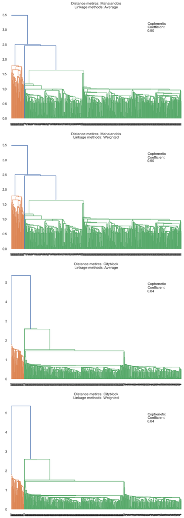

```python
# Create a subplot image
fig, axs = plt.subplots(len(distance_metrics)+len(distance_metrics), 1, figsize=(10, 30))
i=0
for dm in distance_metrics:
    for lm in linkage_methods:
        Z = linkage(subset_scaled_df, metric=dm)
        dendrogram(Z,  ax=axs[i]);
        axs[i].set_title('Distance metircs: {}\nLinkage methods: {}'.format(dm,lm))
        coph_corr, coph_dist = cophenet(Z, pdist(subset_scaled_df))
        axs[i].annotate(f'Cophenetic\nCoefficient\n{coph_corr:0.2f}',
                        (0.80, 0.80),
                        xycoords='axes fraction')
        axs[i].set_title('Distance metircs: {}\nLinkage methods: {}'.format(dm,lm))
        i +=1
```

## Creating 3 Clusters

```python
#Trying with K value as 3
HCmodel = AgglomerativeClustering(n_clusters=3,affinity='euclidean', linkage='ward')
HCmodel.fit(subset_scaled_df)
subset_scaled_df['HC_Clusters'] = HCmodel.labels_
```

```python
df['HC_Clusters'] = HCmodel.labels_
```

```python
cluster_profile = df.groupby('HC_Clusters').mean()
```

```python
cluster_profile['count_in_each_segments'] = df.groupby('HC_Clusters')['Avg_Credit_Limit'].count().values
```

```python
# lets display cluster profile
cluster_profile.style.highlight_max(color = 'lightgreen', axis = 0)
```

[output not shown]

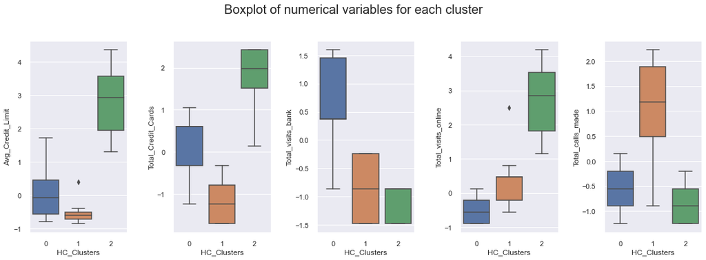

```python
#scaled values
fig, axes = plt.subplots(1, 5,  figsize=(16, 6))
fig.suptitle('Boxplot of numerical variables for each cluster', fontsize=20)
counter = 0
for ii in range(5):
    sns.boxplot(ax=axes[ii],y=subset_scaled_df[all_col[counter]],x=subset_scaled_df['HC_Clusters'])
    counter = counter+1

fig.tight_layout(pad=2.0)
```

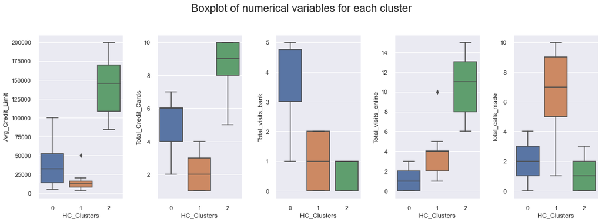

```python
#raw values
fig, axes = plt.subplots(1, 5,  figsize=(16, 6))
fig.suptitle('Boxplot of numerical variables for each cluster', fontsize=20)
counter = 0
for ii in range(5):
    sns.boxplot(ax=axes[ii],y=df[all_col[counter]],x=df['HC_Clusters'])
    counter = counter+1

fig.tight_layout(pad=2.0)
```

### Observations & Insights:

First and foremost, I will first state that the clusters formed by both K-Means and Hierarchical Clustering are EXTREMELY similar, if not identical. I think our ability to form these exact 3 distinct clusters by 2 separate methods is a sign that these 3 clusters are real and clear enough that we can explore our demographic further by making notes of these individuals who fall into these clusters. With this being said, I will continue with the insights and observations.

Cluster 0:

- These customers have an average credit limit around the average credit limit of the sample. 75% of individuals in this cluster have an average credit limit of 50k or lower.
- These customers have only slightly more credit cards than average.
- Customers of this cluster greatly prefer to visit the bank in person as opposed to calling or visiting the website. This is noted by the fact that the individuals tend to visit the bank more than average and call and visit the website less than the other two clusters, except for Cluster 2, who call even less frequently than Cluster 0.

Cluster 1:

- Customers of Cluster 1 have by FAR much lower credit limits than the average, being almost an entire standard deviation lower.
- 50% of these customers only have 2 credit cards, which is notably lower than the average of 5 cards. Also when looking at this particular trait, these individuals are even greater than 1 whole standard deviation below the mean.
- 75% of these customers only visit the bank twice, with 50% only visiting once.
- If these customers are seeking assistance, they opt to make phone calls. This is noted by the fact that they make more calls to the bank than the other 2 clusters by far.
- Even though these customers will visit online slightly more than average, they will still much prefer to make a phone call to seek assistance.

Cluster 2:

- Cluster 2 is the high profile customer.
- These customers have incredibly high credit limits and a large amount of credit cards, much higher than the average in both categories.
- These customers are highly independent. They prefer to visit online for all of their banking needs, visiting online far, FAR more frequently than the other clusters.
- These individuals visit the bank and make phone calls to the bank FAR less frequently than the other two clusters, making even fewer phone calls than Cluster 0. As noted earlier, these customers are highly independent.

## Conclusions & Business Recommendations:

### Conclusions:

As a researcher, I believe one of the best feelings is being able to replicate results. What does a result mean if only able to be achieved once? The fact that we were able to get the same 3 distinct clusters through 2 different methods (K-Means Clustering and Hierarchical Clustering) is amazing to me. I believe that in this dataset, we've truly done good work and were able to find clusters that could further help us in marketing and demographic exploration in order to learn more about what kinds of individuals make up these 3 clusters.

### Business Recommendations:

- Cluster 0 seems to be the idea of the truly "average" customer. Though not literal in terms of statistical analysis, I believe the Cluster 0 customer is a "sweet spot" customer. These customers don't require too much assistance and they are not too complicated with their desires. They seek help quickly and in-person at the bank. I believe that these customers don't like to complicate things by attempting to figure things out online by themselves or over the phone. They are simple, average, and the most easygoing customer. I believe that in the future, when marketing a new product, these customers should be the target demographic as they are truly the "average" in terms of the AllLife Bank customer.
- Cluster 1 customers need more help. Perhaps they're new to banking? Perhaps they are young? We can do demographic exploration to gain more insight on this cluster, however these are individuals with low credit limits and not many cards. As previously stated, this could be because they're young or new to banking or even perhaps because they need financial assistance. These individuals need help when it comes to banking. They come to the bank less frequently than Cluster 0 without a doubt, however they make far more calls than either of 2 clusters. In the future, when attempting to market to this demographic, I recommend perhaps an "accessible" product with a lot of forgiveness. For example, when introducing banking products to this cluster, I would recommend a simple product with no annual fees or low interest rates. I believe after these customers become accustomed to AllLife Bank and our products, they can grow to become Cluster 0 or even Cluster 2.
- Cluster 2, I believe, is by far the most distinct cluster. These customers are independent and affluent. These are individuals with a lot of experience with banking and do not require much assistance as they opt to figure things out themselves online. They make very few visits to the bank and with even fewer phone calls ever made than either of the 2 clusters. In the future, when marketing to this cluster, I believe that this is the ideal cluster to offer premium banking products and services. I would perhaps suggest a credit with high interest rates but with high credit limits and zero foreign transaction fees. These individuals are the least of the AllLife Bank's worries from my perspective. I believe that customers who fall into Cluster 2 are high value customers. These customers are the money-makers for AllLife Bank and we should look to retain them to the best of our ability.